# Practical Machine Learning - Prediction Assignment Writeup

Eduardo Avaria

Thursday, June 19, 2015

## Background

Using devices such as Jawbone Up, Nike FuelBand, and Fitbit it is now possible to collect a large amount of data about personal activity relatively inexpensively. These type of devices are part of the quantified self movement - a group of enthusiasts who take measurements about themselves regularly to improve their health, to find patterns in their behavior, or because they are tech geeks. One thing that people regularly do is quantify how much of a particular activity they do, but they rarely quantify how well they do it.

In this project, we will use data from accelerometers on the belt, forearm, arm, and dumbell of 6 participants. They were asked to perform barbell lifts correctly and incorrectly in 5 different ways. More information is available from the website here: http://groupware.les.inf.puc-rio.br/har.

## Libraries Required

```r
library(caret)
```

```r
library(rpart)
library(rpart.plot)
library(randomForest)
library(corrplot)
```

### Downloading the Data

The following code takes care of checking if the data is local, and if not, downloading it.

```r
trainUrl <-"http://d396qusza40orc.cloudfront.net/predmachlearn/pml-training.csv"
testUrl <- "http://d396qusza40orc.cloudfront.net/predmachlearn/pml-testing.csv"
trainFile <- "./data/pml-training.csv"
testFile  <- "./data/pml-testing.csv"
if (!file.exists("./data")) {
  dir.create("./data")
}
if (!file.exists(trainFile)) {
  download.file(trainUrl, destfile=trainFile, method="curl")
}
if (!file.exists(testFile)) {
  download.file(testUrl, destfile=testFile, method="curl")
}
```

### Read the Data

At this point, we know that the data is available, so we load it into memory

```r
importedTrain <- read.csv("./data/pml-training.csv")
importedTest <- read.csv("./data/pml-testing.csv")
dim(importedTrain)
```

```
## [1] 19622   160
```

```r
dim(importedTest)
```

```
## [1]  20 160
```

The data consists in a training set, consisting of 19622 observations and a testing set with 20 observations that need to be classified into one of the 5 available type of record, as described by the ‘classe’ in the training set. Both datasets contain 160 columns originally, but we will manually explore them, and use our understanding of the situation to remove the columns that don’t seem usefull for determining to which classe the record belongs.

### Clean the data

The first cleaning performed is removing the columns that don’t have any data

```r
noNaTrain <- importedTrain[, colSums(is.na(importedTrain)) == 0]
importedTest <- importedTest[, colSums(is.na(importedTest)) == 0]
```

Next, after a manual inspection of the data, we remove the timestamp data, since that information is not useful for identifying the classe of the record.

```r
classe <- noNaTrain$classe
trainRemove <- grepl("^X|timestamp|window", names(noNaTrain))
filteredTrain <- noNaTrain[, !trainRemove]
cleanTrain <- filteredTrain[, sapply(filteredTrain, is.numeric)]
cleanTrain$classe <- classe
testRemove <- grepl("^X|timestamp|window", names(importedTest))
filteredTest <- importedTest[, !testRemove]
cleanTest <- filteredTest[, sapply(filteredTest, is.numeric)]
sum(complete.cases(cleanTrain))
```

```
## [1] 19622
```

```r
setdiff(names(filteredTest),names(filteredTrain))
```

```
## [1] "problem_id"
```

### Slice the data

Now that we believe that our data is clean enough for modeling, we will split the training data into training and validation chunks. For this, we will use a 60-40 approach, using a random (manually set) seed.

```r
set.seed(8358) # Generated at random.org
inTrain <- createDataPartition(cleanTrain$classe, p=0.60, list=F)
trainData <- cleanTrain[inTrain, ]
valData <- cleanTrain[-inTrain, ]
```

## Data Modeling

At this point, we will construct a random forest model using the column classe as label and the 52 columns left as predictors. To account for the randomization of the forest we will bootstrap the dataset on 25 iterations, and will use 260 (predictors*5)trees.

```r
controlRf <- trainControl(method="boot", 25)
RF <- train(classe ~ ., data=trainData, method="rf", trControl=controlRf, ntree=260)
RF
```

```
## Random Forest
##
## 11776 samples
##    52 predictor
##     5 classes: 'A', 'B', 'C', 'D', 'E'
##
## No pre-processing
## Resampling: Bootstrapped (25 reps)
##
## Summary of sample sizes: 11776, 11776, 11776, 11776, 11776, 11776, ...
##
## Resampling results across tuning parameters:
##
##   mtry  Accuracy   Kappa      Accuracy SD  Kappa SD
##    2    0.9848193  0.9807958  0.002734666  0.003457117
##   27    0.9844886  0.9803794  0.002911838  0.003686953
##   52    0.9747981  0.9681214  0.004764019  0.006037849
##
## Accuracy was used to select the optimal model using  the largest value.
## The final value used for the model was mtry = 2.
```

At this point, we will use the validation data to check the behaviour of our model, making sure that it’s general enough to accept unlabeled data.

```r
predictRF <- predict(RF, valData)
confusionMatrix(valData$classe, predictRF)
```

```
## Confusion Matrix and Statistics
##
##           Reference
## Prediction    A    B    C    D    E
##          A 2223    7    0    0    2
##          B   12 1491   15    0    0
##          C    0   17 1350    1    0
##          D    0    0   26 1260    0
##          E    0    0    3    2 1437
##
## Overall Statistics
##
##                Accuracy : 0.9892
##                  95% CI : (0.9866, 0.9913)
##     No Information Rate : 0.2849
##     P-Value [Acc > NIR] : < 2.2e-16
##
##                   Kappa : 0.9863
##  Mcnemar's Test P-Value : NA
##
## Statistics by Class:
##
##                      Class: A Class: B Class: C Class: D Class: E
## Sensitivity            0.9946   0.9842   0.9684   0.9976   0.9986
## Specificity            0.9984   0.9957   0.9972   0.9961   0.9992
## Pos Pred Value         0.9960   0.9822   0.9868   0.9798   0.9965
## Neg Pred Value         0.9979   0.9962   0.9932   0.9995   0.9997
## Prevalence             0.2849   0.1931   0.1777   0.1610   0.1834
## Detection Rate         0.2833   0.1900   0.1721   0.1606   0.1832
## Detection Prevalence   0.2845   0.1935   0.1744   0.1639   0.1838
## Balanced Accuracy      0.9965   0.9899   0.9828   0.9968   0.9989
```

```r
postResample(predictRF, valData$classe)
```

```
##  Accuracy     Kappa
## 0.9891665 0.9862960
```

```r
1 - as.numeric(confusionMatrix(valData$classe, predictRF)$overall[1])
```

```
## [1] 0.01083355
```

We can see that with the selected parameters, the model has a 98.9% of accuracy, and we can expect about 1 of 100 of samples missclasified. Since we need it to classify 20, it’s acceptable, allowing us to process the testing dataset.

## Predicting for Test Data Set

```r
prediction <- predict(RF, cleanTest[, -length(names(cleanTest))])
prediction
```

```
##  [1] B A B A A E D B A A B C B A E E A B B B
## Levels: A B C D E
```

## Appendix: Figures

1. Correlation Matrix Visualization

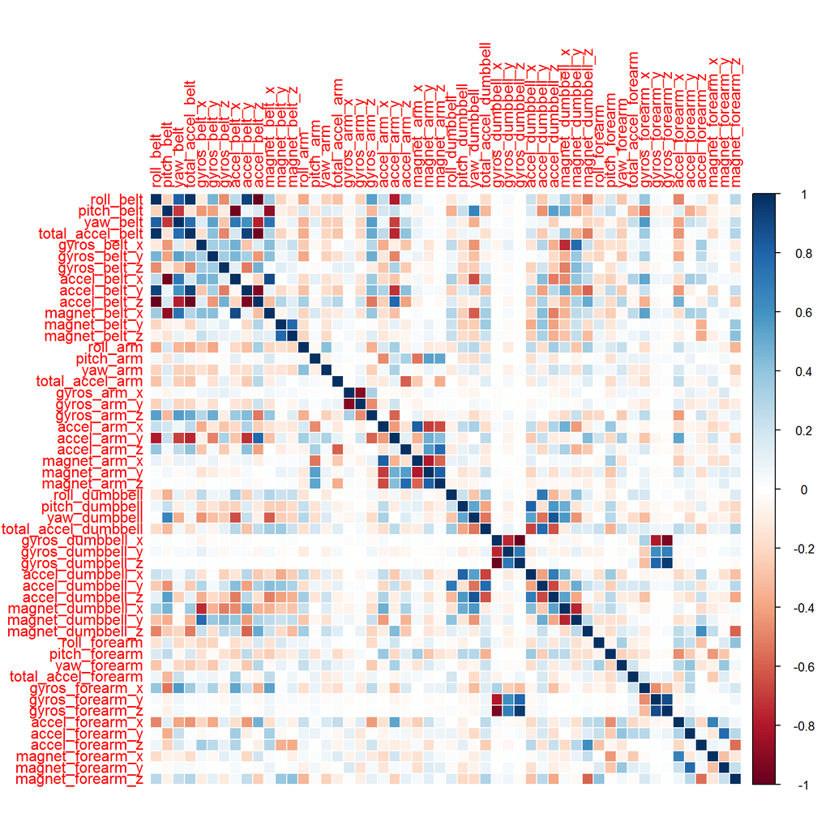

```r
corrPlot <- cor(trainData[, -length(names(trainData))])
corrplot(corrPlot, method="color")
```

2. Graphic representation of the Decision Tree

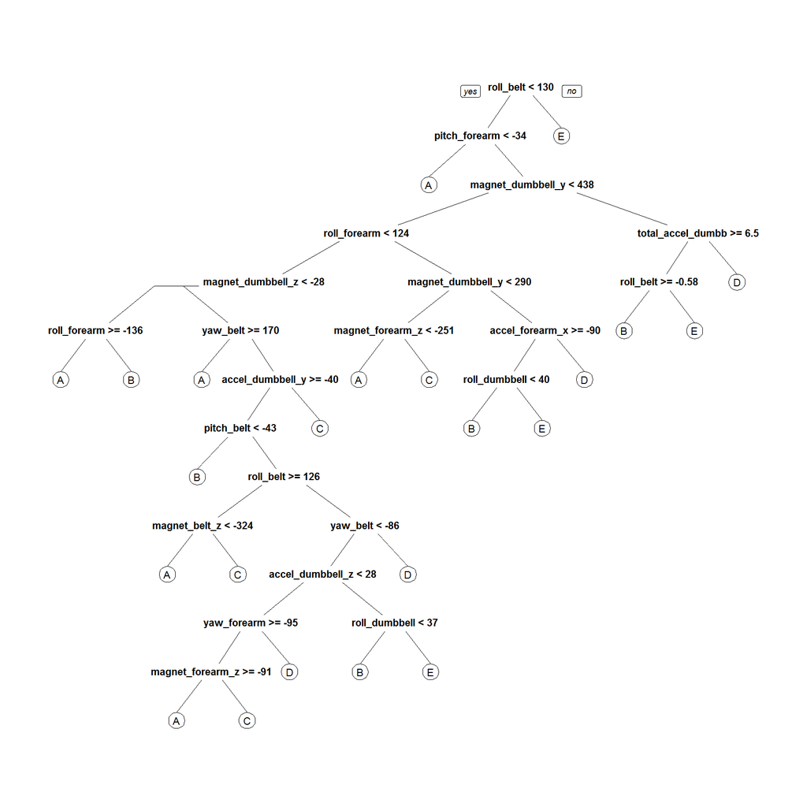

```r
treeModel <- rpart(classe ~ ., data=trainData, method="class")
prp(treeModel)
```